# The Global Atlas

# The global household energy burden atlas

Every figure below is generated from the open-source `emburdensynth` pipeline’s parquet outputs at site-render time. All raw code + data at github.com/ericscheier/emburdensynth.

## Canonical burden — every country in the release

Household energy burden by country, using the 4-tier fallback chain (GCD survey → Eurostat HBS → k-nearest-neighbour imputation by GDP within region → region mean). Border color encodes data-source tier.

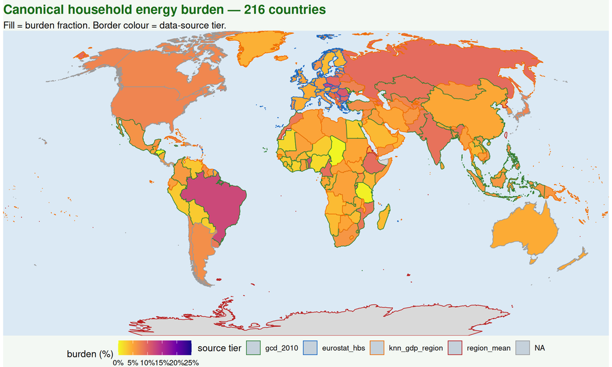

## The climate-justice scatter

Cumulative CO<sub>2</sub> since 1750 (log-x) versus 2020 household energy burden (%). Countries in the upper-left quadrant carry the lowest historical responsibility yet the highest current burden.

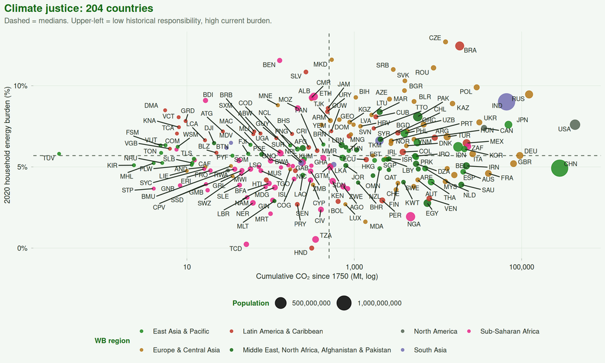

## More in the full technical report

The full 80-page technical report has 39 figures covering:

Layer 0-5

### Map atlas

Cell-level burden, canonical burden, physics-required kWh, energy-limiting share, income, embodied CO<sub>2</sub>, Sub-Saharan Africa focus, South Asia focus.

Cross-signal

### Country typology

PCA biplot, hierarchical correlation matrix, k-means archetype map, elastic-net regression.

Deep history

### 1750 to present

NASA GISTEMP temperature anomalies, OWID CO<sub>2</sub> per fuel, WB WDI 1960, UNDP HDI 1990, Ember decarbonization.

Validation

### Ground-truth checks

Eurostat inability-to-warm, Bland-Altman method agreement, physics-vs-empirical suppression, bootstrap CI width map.

Download the full 80-page report (PDF, 7.2 MB) →